# PSTAT 230: Time Series Consulting

Selin Karabulut, Sophia Arabadjis, Shuying Yu

4/27/2021

# 1 An intuition for time series and data analysis in R

We are using an example data set used in the Appendix by Shumway and Stoffer (2017). Additional examples for code using `R` to explore time series data is also found in Hyndman and Athanasopoulos (n.d.).

Time series data can be thought of as data consistently measured or observed at different points in time. In this way, the data have an implicit *order* or flow, and questions about time series data often involve questions about change over time.

```r
#Libraries
library(tidyverse)
library(lubridate)
library(PerformanceAnalytics)
library(Hmisc)
library(astsa)
library(ggfortify)

# Load data sets
data("cmort")
data("part")
cmort <- cmort
part <- part
paste("Particulate Matter Data", paste(head(part), collapse = " "))
```

```
## [1] "Particulate Matter Data 72.72 49.6 55.68 55.16 66.02 44.01"
```

```r
paste("Cardiac Mortality Data", paste(head(cmort),collapse = " "))
```

```
## [1] "Cardiac Mortality Data 97.85 104.64 94.36 98.05 95.85 95.98"
```

As a running example, we can work with three data sets from Shumway and Stoffer’s 2017 book Shumway and Stoffer (2017).

1. The first data set is called `cmort` and captures the average weekly cardiovascular mortality in Los Angeles County from 1970 to 1980.
2. The second data set is called `part` and captures the average weekly particulate matter concentration in Los Angeles County from 1970 to 1980.
3. The third data set is called `temp` and captures the average weekly temperature in Los Angeles County from 1970 to 1980.

We can instruct the `R` to read and format each data set using `ts(data, start=(),frequency)` arguments, where in the `start` we dictate the year and week of the data start, and the frequency specifies how many weeks (52) to consider. Using `ts` objects is very handy because we don’t have to store and manipulate dates (if they are regular interval), and visualization becomes easier.

```r
## Load in and save data from astsa package
data(cmort)
cmort <- cmort
data(tempr)
tempr <- tempr
data(part)
part <- part
## Save as ts objects
cmort.ts <- ts(cmort, start = c(1970,1),frequency = 52)
cmort.ts
```

```
## Time Series:
## Start = c(1970, 1)
## End = c(1979, 40)
## Frequency = 52
##   [1]  97.85 104.64  94.36  98.05  95.85  95.98  88.63  90.85  92.06  88.75
##  [11]  94.60  92.86  98.02  87.64  97.40  83.24  86.60  90.69  82.86  99.06
##  [21]  81.00  93.18  86.86  89.35  87.13  88.39  85.38  83.96  84.95  86.81
##  [31]  85.25  94.72  90.96  87.73  92.58  87.02  92.68  97.95  94.19  93.95
##  [41]  92.29  93.48  97.41  96.98 106.60 112.41 118.59 107.90 111.82 102.78
##  [51] 100.63 106.54 105.39 104.99 102.72 104.67 103.30  98.46 100.78  94.43
##  [61]  92.16  92.13  95.04  86.88  95.29  85.39  92.63  88.72  87.09  83.92
##  [71]  89.01  78.14  92.84  88.65  86.66  82.04 105.15  94.19  83.99  88.22
##  [81]  85.59  99.21  87.77  90.39  82.25 102.92  86.84  97.22  94.97 104.86
##  [91]  80.53 102.47  97.80  95.28 105.64 106.44 110.65 114.41 115.98 112.72
## [101] 115.99 104.14 109.30 111.47 102.67 101.34  94.97  90.48  93.70  81.87
```

[output cut: 40 more lines]

```r
part.ts <- ts(part, start = c(1970,1), frequency = 52)
part.ts
```

```
## Time Series:
## Start = c(1970, 1)
## End = c(1979, 40)
## Frequency = 52
##   [1] 72.72 49.60 55.68 55.16 66.02 44.01 47.83 43.60 24.99 40.41 51.93 32.26
##  [13] 73.65 30.15 41.10 41.53 29.46 51.13 41.37 59.49 48.25 51.73 44.21 59.59
##  [25] 60.82 55.01 50.59 55.05 48.00 55.37 64.44 75.00 61.46 50.04 49.90 51.14
##  [37] 77.88 46.71 73.86 76.87 39.85 71.52 63.87 48.81 68.82 64.39 81.76 73.55
##  [49] 67.99 75.37 65.23 69.91 44.34 40.80 55.09 38.44 53.54 42.46 53.22 44.41
##  [61] 31.29 31.10 35.92 37.73 35.00 36.25 22.75 32.26 34.77 52.73 36.59 30.04
##  [73] 49.91 42.60 35.89 41.76 47.03 36.62 31.40 46.76 30.60 60.58 33.30 50.08
##  [85] 46.99 73.07 50.28 71.60 50.09 82.85 58.36 62.63 71.27 50.85 65.13 74.74
##  [97] 39.59 69.67 84.23 84.96 67.68 58.62 57.02 64.58 63.25 56.92 46.59 49.20
## [109] 48.55 39.16 43.59 43.26 35.86 40.40 44.84 28.72 44.40 24.24 37.13 38.01
## [121] 32.22 32.86 25.83 37.95 36.93 34.03 27.68 52.62 36.51 33.53 39.94 36.85
```

[output cut: 32 more lines]

```r
temp.ts <- ts(tempr, start=c(1970,1), frequency = 52)
temp.ts
```

```
## Time Series:
## Start = c(1970, 1)
## End = c(1979, 40)
## Frequency = 52
##   [1] 72.38 67.19 62.94 72.49 74.25 67.88 74.20 74.88 64.17 67.09 78.29 68.07
##  [13] 86.70 69.43 75.22 77.29 69.96 79.35 82.94 89.79 80.19 87.58 81.76 86.79
##  [25] 87.46 88.21 83.40 86.10 82.16 81.31 78.99 92.56 84.50 76.44 73.97 69.63
##  [37] 81.05 69.57 78.05 70.61 60.95 67.74 68.50 54.84 60.58 62.14 51.26 72.55
##  [49] 64.42 78.25 59.17 80.89 58.63 62.50 67.52 63.56 74.87 64.98 82.70 72.63
##  [61] 65.36 63.33 66.10 64.85 76.37 75.27 65.15 69.62 72.81 85.57 78.58 77.32
##  [73] 87.27 86.29 83.55 88.57 95.34 88.18 82.71 89.80 81.63 98.95 82.58 79.74
##  [85] 77.31 99.88 69.19 76.29 64.28 78.61 65.87 68.18 65.98 63.95 57.65 64.27
##  [97] 55.18 63.52 63.95 69.91 58.90 65.25 62.79 71.43 68.72 66.96 75.68 68.57
## [109] 68.62 69.61 71.89 73.66 70.67 69.90 80.23 67.16 81.71 66.20 80.79 84.12
## [121] 75.52 81.55 75.88 82.45 84.86 84.93 79.73 97.20 85.97 82.00 81.95 83.56
```

[output cut: 32 more lines]

The first thing we might want to do is simply visualize the data. Because the `cmort`,`tempr` and `part` time series are all on the same time scale (weekly, 1970-1980), we can plot them on the same plot.

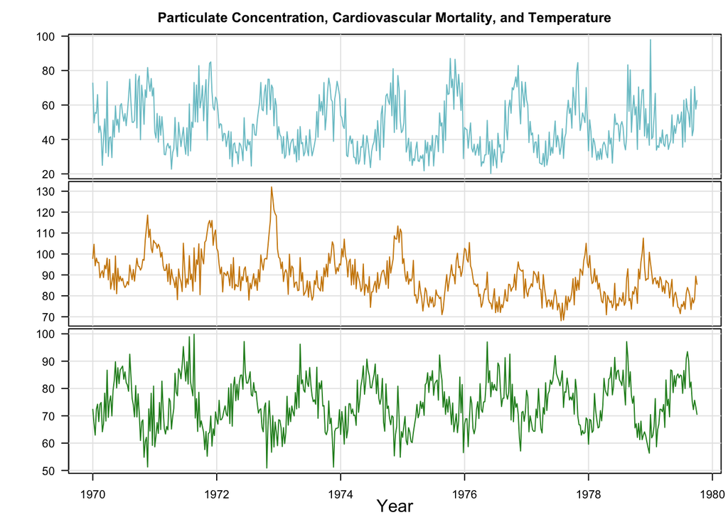

```r
#Set figure parameters
layout(matrix(c(1:3, 1:3), ncol=2), height=c(.5,.5, .5))
par(mar=c(.2,2,0,.5), oma=c(3.2,3,2.5,0), las=1)

#Particulate matter
plot(part.ts, type='n', xaxt='no', ylab='PM Conc.')
grid(lty=1, col=gray(.9))
lines(part.ts, col = "cadetblue3")

#Cardiovascular mortality
plot(cmort.ts, type='n', xaxt='no', ylab='Cardiac Mortality')
grid(lty=1, col=gray(.9))
lines(cmort.ts, col="orange3")

#Temperature
plot(temp.ts, type='n', ylab="Temperature")
grid(lty=1, col=gray(.9))
lines(temp.ts, col="forestgreen")

#Labels
mtext(side=1, "Year", line=2)
title(main = "Particulate Concentration, Cardiovascular Mortality, and Temperature", outer = T)
```

The first subplot (blue line) shows the weekly average particulate matter concentration. The next subplot (orange line) shows the weekly cardiovascular death count. The final line in green shows the average weekly temperature. From a descriptive stand point, a few things stand out about this plot:

All of these lines exhibit a *periodicity* or repetivite cycle of peaks and troughs. The peaks in the particulate matter line (blue) and peaks in the cardiovascular mortality line (orange) are relatively similar – they seem to occur within close proximity of each other.

The green line (temperature) appears to be somewhat offset from the cardiovascular and particulate matter lines.

Down the line, we may eventually be interested in exploring the relationship (if any) between these time series.

For now, we’ll focus on one time series (cardiovascular mortality) and return to the question of multivariate time series later.

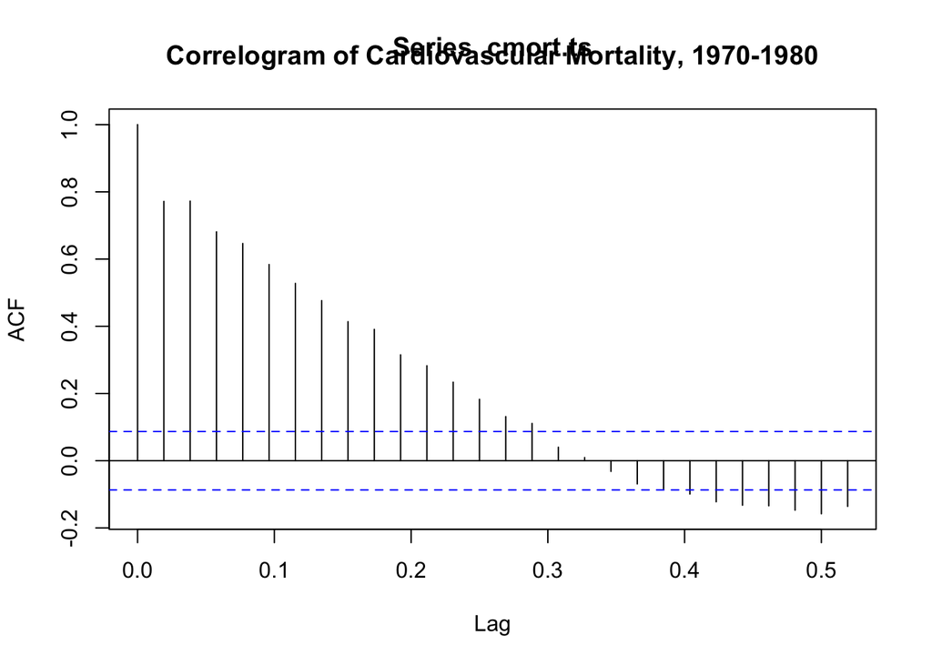

```r
acf(cmort.ts,plot=T, type = "correlation",title=F)
title("Correlogram of Cardiovascular Mortality, 1970-1980")
```

# 2 Exploratory data analysis for time series data in R

To measure dependence, we can use an **autocorrelation function (ACF)** in a time series model. ACF measures the linear predictability of the time series at time $s$ using only its adjacent value at time $s-1$ (Shumway and Stoffer 2006). This can be done by using a linear combination of inputs. Thus, ACF provides the ability to forecast the series at time $s+1$ from the value at time $s$.

What we also can do is plot the temperature data as another series to observe how particulate matter and cardiovascular mortality covary.

Note the strong seasonal components in all of the series, corresponding to winter-summer variations and the downward trend in the cardiovascular mortality over the 10-year period (Shumway and Stoffer 2006, 2017).

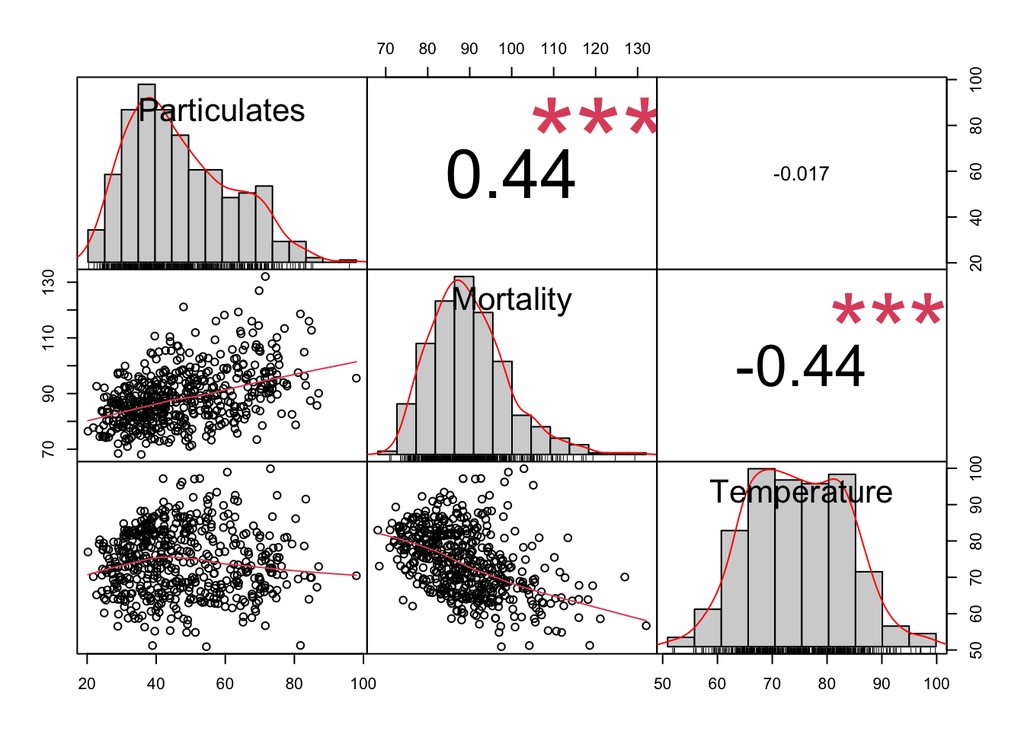

```r
#Correlation, scatter plots, and bivariate regression
df <- cbind(Particulates=part,
            Mortality=cmort,
            Temperature=tempr)
chart.Correlation(df)
```

Correlation matrix for the different time series. The diagonal displays the histogram and kernel density estimates of the variables. The lower off-diagonal shows the bivariate scatterplots with a lowess fitted line, and the upper off-diagonal shows the Pearson’s *R* coefficient with significance levels ($\cdot$ p < 0.1, ** p < 0.01, *** p < 0.001).

The scatterplots indicate a possible linear relation between mortality and the pollutant particulates, and between mortality and temperature.

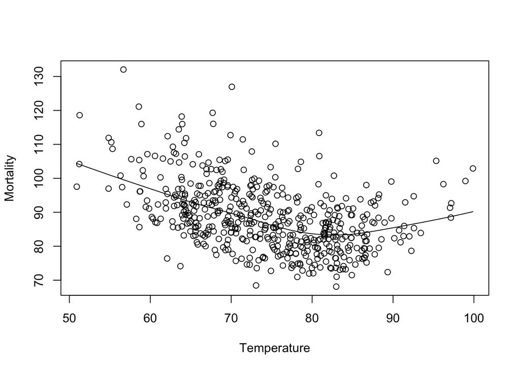

```r
plot(tempr, cmort, xlab="Temperature", ylab="Mortality")
lines(lowess(tempr, cmort))
```

# 3 Modeling time series in R

```r
#Summary
summary(df)
```

```
##   Particulates     Mortality       Temperature
##  Min.   :20.25   Min.   : 68.11   Min.   :50.91
##  1st Qu.:35.85   1st Qu.: 81.90   1st Qu.:67.23
##  Median :44.25   Median : 87.33   Median :74.06
##  Mean   :47.41   Mean   : 88.70   Mean   :74.26
##  3rd Qu.:57.54   3rd Qu.: 94.36   3rd Qu.:81.49
##  Max.   :97.94   Max.   :132.04   Max.   :99.88
```

```r
#Center temperature
temp <- tempr-mean(tempr)
temp2 <- temp^2
trend <- time(cmort) # time

#Linear regression fit
summary(fit <- lm(cmort~ trend + temp + temp2 + part, na.action=NULL))
```

```
##
## Call:
## lm(formula = cmort ~ trend + temp + temp2 + part, na.action = NULL)
##
## Residuals:
##      Min       1Q   Median       3Q      Max
## -19.0760  -4.2153  -0.4878   3.7435  29.2448
##
## Coefficients:
##               Estimate Std. Error t value Pr(>|t|)
## (Intercept)  2.831e+03  1.996e+02   14.19  < 2e-16 ***
## trend       -1.396e+00  1.010e-01  -13.82  < 2e-16 ***
## temp        -4.725e-01  3.162e-02  -14.94  < 2e-16 ***
## temp2        2.259e-02  2.827e-03    7.99 9.26e-15 ***
## part         2.554e-01  1.886e-02   13.54  < 2e-16 ***
## ---
## Signif. codes:  0 '***' 0.001 '**' 0.01 '*' 0.05 '.' 0.1 ' ' 1
##
## Residual standard error: 6.385 on 503 degrees of freedom
## Multiple R-squared:  0.5954, Adjusted R-squared:  0.5922
## F-statistic:   185 on 4 and 503 DF,  p-value: < 2.2e-16
```

```r
#ANOVA table (compare to next line)
summary(aov(fit))
```

```
##              Df Sum Sq Mean Sq F value Pr(>F)
## trend         1  10667   10667  261.62 <2e-16 ***
## temp          1   8607    8607  211.09 <2e-16 ***
## temp2         1   3429    3429   84.09 <2e-16 ***
## part          1   7476    7476  183.36 <2e-16 ***
## Residuals   503  20508      41
## ---
## Signif. codes:  0 '***' 0.001 '**' 0.01 '*' 0.05 '.' 0.1 ' ' 1
```

```r
summary(aov(lm(cmort~cbind(trend, temp, temp2, part))))
```

```
##                                  Df Sum Sq Mean Sq F value Pr(>F)
## cbind(trend, temp, temp2, part)   4  30178    7545     185 <2e-16 ***
## Residuals                       503  20508      41
## ---
## Signif. codes:  0 '***' 0.001 '**' 0.01 '*' 0.05 '.' 0.1 ' ' 1
```

```r
#AIC, BIC, AICc
num <- length(cmort) # sample size
AIC(fit)/num - log(2*pi) # AIC
```

```
## [1] 4.721732
```

```r
BIC(fit)/num - log(2*pi) # BIC
```

```
## [1] 4.771699
```

```r
(AICc <- log(sum(resid(fit)^2)/num) + (num+5)/(num-5-2)) #AiCc
```

```
## [1] 4.722062
```

We can relate mean adjusted temperature and particulate levels to cardiovascular mortality.

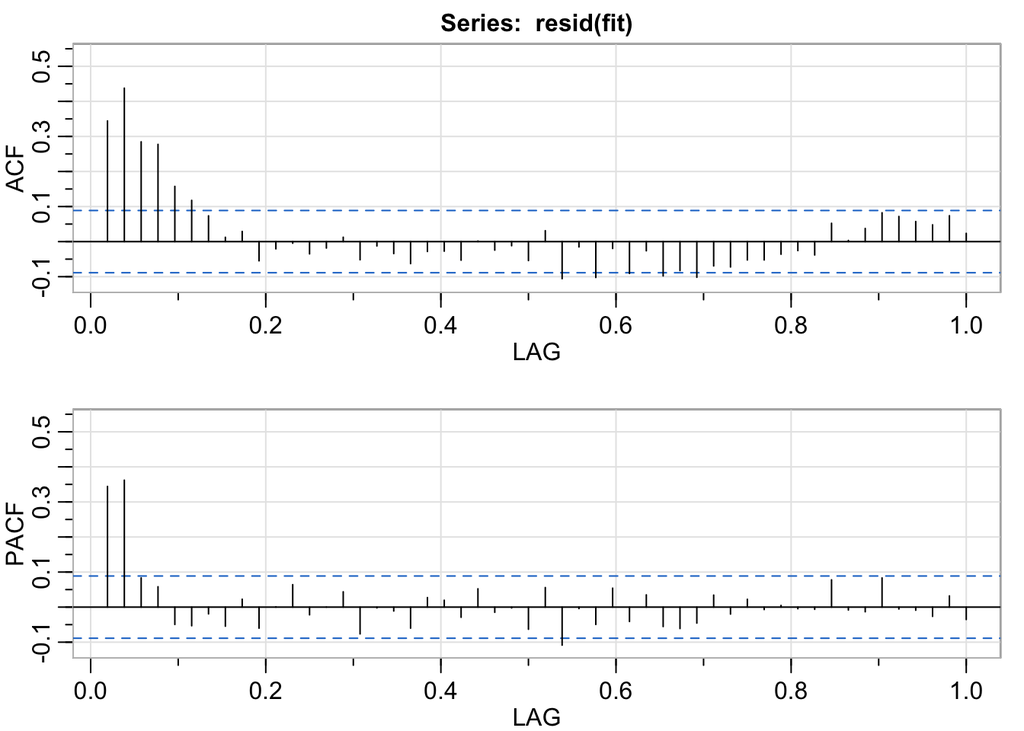

```
##      [,1] [,2] [,3] [,4]  [,5]  [,6]  [,7]  [,8] [,9] [,10] [,11] [,12] [,13]
## ACF  0.34 0.44 0.28 0.28  0.16  0.12  0.07  0.01 0.03 -0.05 -0.02  0.00 -0.04
## PACF 0.34 0.36 0.08 0.06 -0.05 -0.05 -0.02 -0.05 0.02 -0.06  0.00  0.06 -0.02
##      [,14] [,15] [,16] [,17] [,18] [,19] [,20] [,21] [,22] [,23] [,24] [,25]
## ACF  -0.02  0.01 -0.05 -0.01 -0.03 -0.06 -0.03 -0.03 -0.05  0.00 -0.02 -0.01
## PACF  0.00  0.04 -0.08  0.00 -0.01 -0.06  0.03  0.02 -0.03  0.05 -0.01  0.00
##      [,26] [,27] [,28] [,29] [,30] [,31] [,32] [,33] [,34] [,35] [,36] [,37]
## ACF  -0.05  0.03 -0.11 -0.02 -0.10 -0.02 -0.09 -0.03 -0.10 -0.08 -0.10 -0.07
## PACF -0.06  0.06 -0.11  0.00 -0.05  0.05 -0.04  0.04 -0.06 -0.06 -0.05  0.03
##      [,38] [,39] [,40] [,41] [,42] [,43] [,44] [,45] [,46] [,47] [,48] [,49]
## ACF  -0.07 -0.05 -0.05 -0.04 -0.03 -0.04  0.05  0.00  0.04  0.08  0.07  0.06
## PACF -0.02  0.02 -0.01  0.00  0.00 -0.01  0.08 -0.01 -0.01  0.08 -0.01 -0.01
##      [,50] [,51] [,52]
## ACF   0.05  0.07  0.02
## PACF -0.03  0.03 -0.04
```

```r
#ACF
acf2(resid(fit), 52) # implies AR2
```

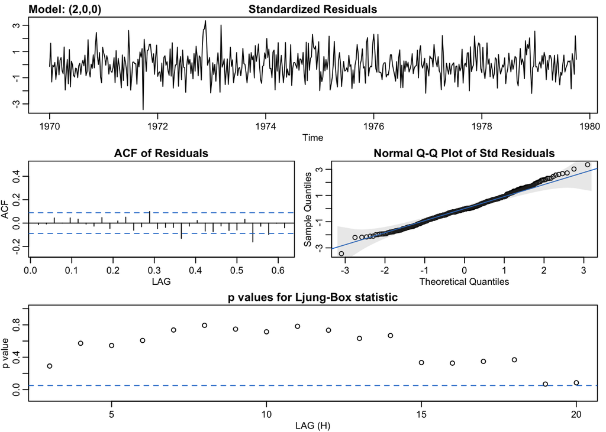

```
## $fit
##
## Call:
## stats::arima(x = xdata, order = c(p, d, q), seasonal = list(order = c(P, D,
##     Q), period = S), xreg = xreg, transform.pars = trans, fixed = fixed, optim.control = list(trace = trc,
##     REPORT = 1, reltol = tol))
##
## Coefficients:
##          ar1     ar2  intercept    trend     temp   temp2    part
##       0.3848  0.4326  3075.1482  -1.5165  -0.0190  0.0154  0.1545
## s.e.  0.0436  0.0400   834.7286   0.4226   0.0495  0.0020  0.0272
##
## sigma^2 estimated as 26.01:  log likelihood = -1549.04,  aic = 3114.07
##
## $degrees_of_freedom
## [1] 501
##
## $ttable
##            Estimate       SE t.value p.value
## ar1          0.3848   0.0436  8.8329  0.0000
## ar2          0.4326   0.0400 10.8062  0.0000
## intercept 3075.1482 834.7286  3.6840  0.0003
## trend       -1.5165   0.4226 -3.5881  0.0004
## temp        -0.0190   0.0495 -0.3837  0.7014
## temp2        0.0154   0.0020  7.6117  0.0000
## part         0.1545   0.0272  5.6803  0.0000
##
## $AIC
## [1] 6.130066
##
## $AICc
## [1] 6.130507
##
## $BIC
## [1] 6.196687
```

```r
sarima(cmort, 2,0,0, xreg=cbind(trend,temp,temp2,part))
```

We assume that the current value at time *t* is white noise temporarily. The sample ACF and partial ACF (PACF) of the residuals from the ordinary least squares fit of the model. The residual analysis output from `sarima` shows no obvious departure of the residuals from white noise.

## 3.1 Time Series Analysis and Modeling with the Air Passengers Dataset

```r
library(ggfortify)
library(tseries)
library(forecast)
```

```r
data(AirPassengers)
AP <- AirPassengers
# Take a look at the class of the dataset AirPassengers
class(AP)
```

```
## [1] "ts"
```

The AirPassenger dataset in R provides monthly totals of a US airline passengers, from 1949 to 1960. This dataset is already of a time series class therefore no further class or date manipulation is required.

### 3.1.1 PERFORM EXPLORATORY DATA ANALYSIS

```r
# Take a look at the entries
AP
```

```
##      Jan Feb Mar Apr May Jun Jul Aug Sep Oct Nov Dec
## 1949 112 118 132 129 121 135 148 148 136 119 104 118
## 1950 115 126 141 135 125 149 170 170 158 133 114 140
## 1951 145 150 178 163 172 178 199 199 184 162 146 166
## 1952 171 180 193 181 183 218 230 242 209 191 172 194
## 1953 196 196 236 235 229 243 264 272 237 211 180 201
## 1954 204 188 235 227 234 264 302 293 259 229 203 229
## 1955 242 233 267 269 270 315 364 347 312 274 237 278
## 1956 284 277 317 313 318 374 413 405 355 306 271 306
## 1957 315 301 356 348 355 422 465 467 404 347 305 336
## 1958 340 318 362 348 363 435 491 505 404 359 310 337
## 1959 360 342 406 396 420 472 548 559 463 407 362 405
## 1960 417 391 419 461 472 535 622 606 508 461 390 432
```

```r
# Check for missing values
sum(is.na(AP))
```

```
## [1] 0
```

```r
# Check the frequency of the time series
frequency(AP)
```

```
## [1] 12
```

```r
# Check the cycle of the time series
cycle(AP)
```

```
##      Jan Feb Mar Apr May Jun Jul Aug Sep Oct Nov Dec
## 1949   1   2   3   4   5   6   7   8   9  10  11  12
## 1950   1   2   3   4   5   6   7   8   9  10  11  12
## 1951   1   2   3   4   5   6   7   8   9  10  11  12
## 1952   1   2   3   4   5   6   7   8   9  10  11  12
## 1953   1   2   3   4   5   6   7   8   9  10  11  12
## 1954   1   2   3   4   5   6   7   8   9  10  11  12
## 1955   1   2   3   4   5   6   7   8   9  10  11  12
## 1956   1   2   3   4   5   6   7   8   9  10  11  12
## 1957   1   2   3   4   5   6   7   8   9  10  11  12
## 1958   1   2   3   4   5   6   7   8   9  10  11  12
## 1959   1   2   3   4   5   6   7   8   9  10  11  12
## 1960   1   2   3   4   5   6   7   8   9  10  11  12
```

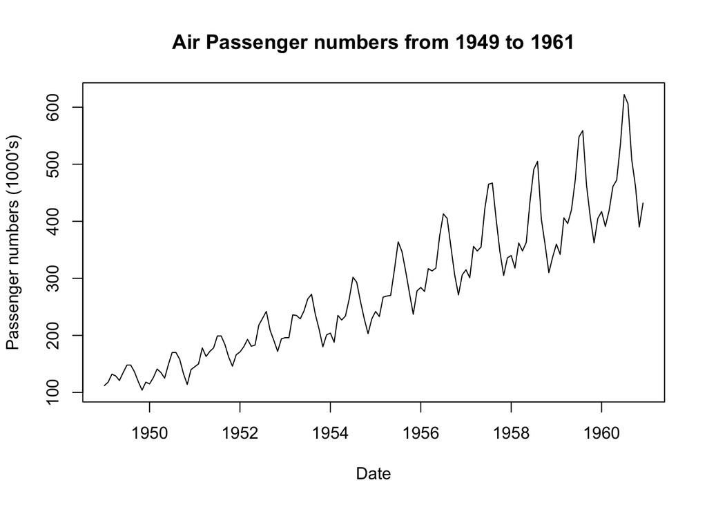

```r
# Plot the raw data using the base plot function
plot(AP,xlab="Date", ylab = "Passenger numbers (1000's)",main="Air Passenger numbers from 1949 to 1961")
```

As an alternative to the base plot function, so we can also use the extension ggfortify R package from the ggplot2 package, to plot directly from a time series. The benefits are not having to convert to a dataframe as required with ggplot2, but still having access to the layering grammar of graphics.

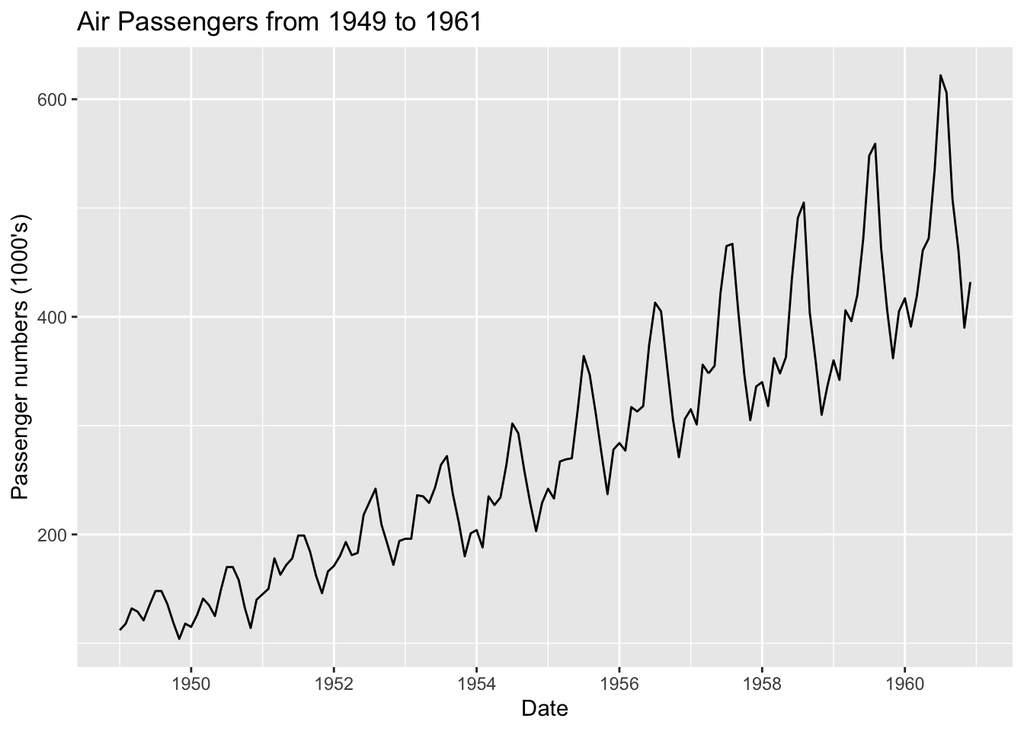

```r
autoplot(AP) + labs(x ="Date", y = "Passenger numbers (1000's)", title="Air Passengers from 1949 to 1961")
```

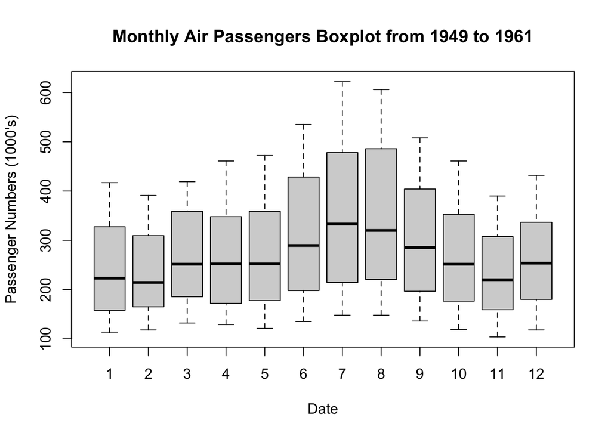

```r
#Let’s use the boxplot function to see any seasonal effects.

boxplot(AP~cycle(AP),xlab="Date", ylab = "Passenger Numbers (1000's)" ,main ="Monthly Air Passengers Boxplot from 1949 to 1961")
```

From these exploratory plots, we can make some initial inferences:

The passenger numbers increase over time with each year which may be indicative of an increasing linear trend, perhaps due to increasing demand for flight travel and commercialisation of airlines in that time period. In the boxplot there are more passengers travelling in months 6 to 9 with higher means and higher variances than the other months, indicating seasonality with a apparent cycle of 12 months. The rationale for this could be more people taking holidays and fly over the summer months in the US. AirPassengers appears to be multiplicative time series as the passenger numbers increase, it appears so does the pattern of seasonality. There do not appear to be any outliers and there are no missing values. Therefore no data cleaning is required.

### 3.1.2 TIME SERIES DECOMPOSITION

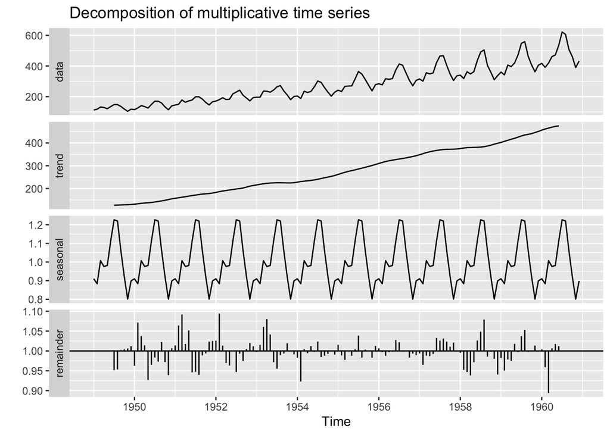

```r
#With this model, we will use the decompose function in R. Continuing to use ggfortify for plots, in one line, autoplot these decomposed #components to further analyse the data.

decomposeAP <- decompose(AP,"multiplicative")
autoplot(decomposeAP)
```

In these decomposed plots we can again see the trend and seasonality as inferred previously, but we can also observe the estimation of the random component depicted under the “remainder”.

### 3.1.3 TEST STATIONARITY OF THE TIME SERIES

A stationary time series has the conditions that the mean, variance and covariance are not functions of time. In order to fit arima models, the time series is required to be stationary. We will use two methods to test the stationarity.

1. Test stationarity of the time series (ADF)

In order to test the stationarity of the time series, let’s run the Augmented Dickey-Fuller Test using the adf.test function from the tseries R package.

First set the hypothesis test:

**The null hypothesis H0**

that the time series is non stationary The alternative hypothesis HA

that the time series is stationary

```r
adf.test(AP)
```

```
##
##  Augmented Dickey-Fuller Test
##
## data:  AP
## Dickey-Fuller = -7.3186, Lag order = 5, p-value = 0.01
## alternative hypothesis: stationary
```

As a rule of thumb, where the p-value is less than 5%, we strong evidence against the null hypothesis, so we reject the null hypothesis. As per the test results above, the p-value is 0.01 which is <0.05 therefore we reject the null in favour of the alternative hypothesis that the time series is stationary.

2. Test stationarity of the time series (Autocorrelation)

Another way to test for stationarity is to use autocorrelation. We will use autocorrelation function (acf) in from the base stats R package. This function plots the correlation between a series and its lags ie previous observations with a 95% confidence interval in blue. If the autocorrelation crosses the dashed blue line, it means that specific lag is significantly correlated with current series.

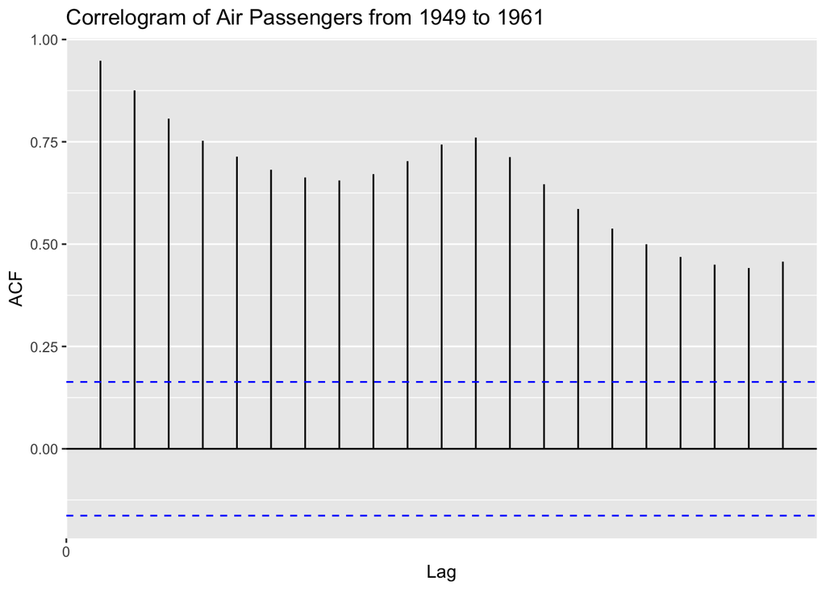

```r
autoplot(acf(AP,plot=FALSE))+ labs(title="Correlogram of Air Passengers from 1949 to 1961")
```

The maximum at lag 1 or 12 months, indicates a positive relationship with the 12 month cycle.

Since we have already created the decomposeAP list object with a random component, we can plot the acf of the decomposeAP$random.

```r
# Review random time series for any missing values
decomposeAP$random
```

```
##            Jan       Feb       Mar       Apr       May       Jun       Jul
## 1949        NA        NA        NA        NA        NA        NA 0.9516643
## 1950 0.9626030 1.0714668 1.0374474 1.0140476 0.9269030 0.9650406 0.9835566
## 1951 1.0138446 1.0640180 1.0918541 1.0176651 1.0515825 0.9460444 0.9474041
## 1952 1.0258814 1.0939696 1.0134734 0.9695596 0.9632673 1.0003735 0.9468562
## 1953 0.9976684 1.0151646 1.0604644 1.0802327 1.0413329 0.9718056 0.9551933
## 1954 0.9829785 0.9232032 1.0044417 0.9943899 1.0119479 0.9978740 1.0237753
## 1955 1.0154046 0.9888241 0.9775844 1.0015732 0.9878755 1.0039635 1.0385512
## 1956 1.0066157 0.9970250 0.9876248 0.9968224 0.9985644 1.0275560 1.0217685
## 1957 0.9937293 0.9649918 0.9881769 0.9867637 0.9924177 1.0328601 1.0261250
## 1958 0.9954212 0.9522762 0.9469115 0.9383993 0.9715785 1.0261340 1.0483841
## 1959 0.9825176 0.9505736 0.9785278 0.9746440 1.0177637 0.9968613 1.0373136
## 1960 1.0039279 0.9590794 0.8940857 1.0064948 1.0173588 1.0120790        NA
##            Aug       Sep       Oct       Nov       Dec
## 1949 0.9534014 1.0022198 1.0040278 1.0062701 1.0118119
## 1950 0.9733720 1.0225047 0.9721928 0.9389527 1.0067914
## 1951 0.9397599 0.9888637 0.9938809 1.0235337 1.0250824
## 1952 0.9931171 0.9746302 1.0046687 1.0202797 1.0115407
## 1953 0.9894989 0.9934337 1.0192680 1.0009392 0.9915039
## 1954 0.9845184 0.9881036 0.9927613 0.9995143 0.9908692
## 1955 0.9831117 1.0032501 1.0003084 0.9827720 1.0125535
## 1956 1.0004765 1.0008730 0.9835071 0.9932761 0.9894251
## 1957 1.0312668 1.0236147 1.0108432 1.0212995 1.0005263
## 1958 1.0789695 0.9856540 0.9977971 0.9802940 0.9405687
## 1959 1.0531001 0.9974447 1.0013371 1.0134608 0.9999192
## 1960        NA        NA        NA        NA        NA
```

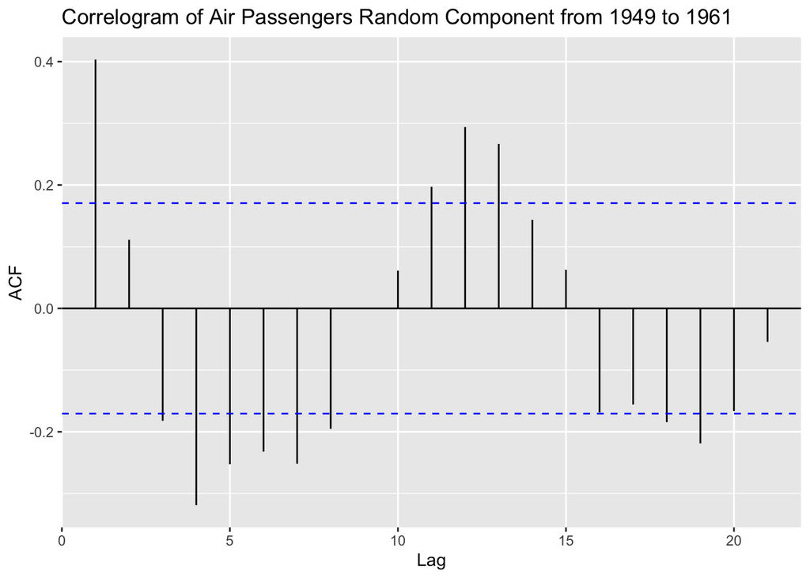

```r
# Autoplot the random time series from 7:138 which exclude the NA values
autoplot(acf(decomposeAP$random[7:138],plot=FALSE))+ labs(title="Correlogram of Air Passengers Random Component from 1949 to 1961")
```

### 3.1.4 FIT A TIME SERIES MODEL

1. Linear Model

Since there is an upwards trend we will look at a linear model first for comparison. We plot AirPassengers raw dataset with a blue linear model.

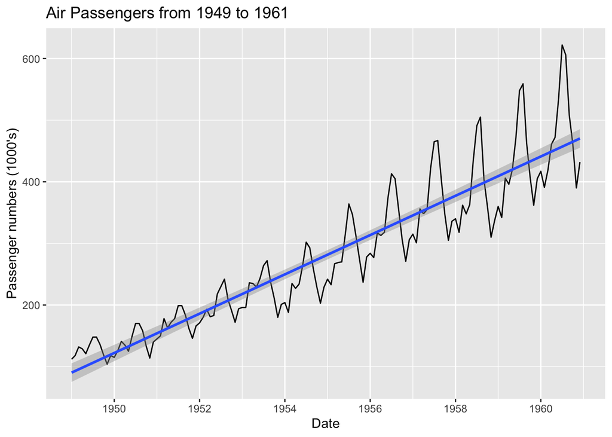

```r
autoplot(AP) + geom_smooth(method="lm")+ labs(x ="Date", y = "Passenger numbers (1000's)", title="Air Passengers from 1949 to 1961")
```

This may not be the best model to fit as it doesn’t capture the seasonality and multiplicative effects over time.

2. ARIMA Model

Use the auto.arima function from the forecast R package to fit the best model and coefficients, given the default parameters including seasonality as TRUE. Note we have used the ARIMA modeling procedure as referenced

```r
arimaAP <- auto.arima(AP)
arimaAP
```

```
## Series: AP
## ARIMA(2,1,1)(0,1,0)[12]
##
## Coefficients:
##          ar1     ar2      ma1
##       0.5960  0.2143  -0.9819
## s.e.  0.0888  0.0880   0.0292
##
## sigma^2 estimated as 132.3:  log likelihood=-504.92
## AIC=1017.85   AICc=1018.17   BIC=1029.35
```

### 3.1.5 CALCULATE FORECASTS

Finally we can plot a forecast of the time series using the forecast function, again from the forecast R package, with a 95% confidence interval where h is the forecast horizon periods in months.

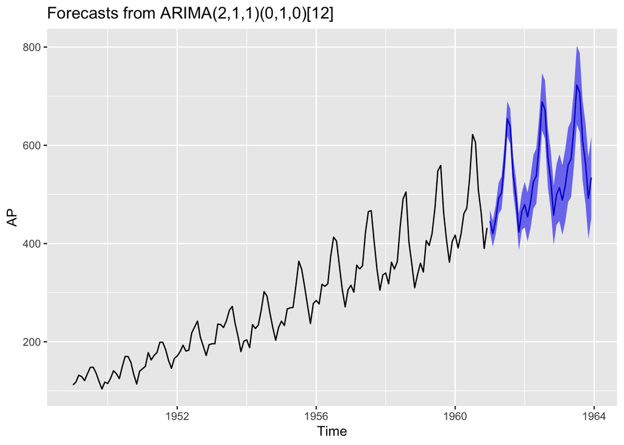

```r
forecastAP <- forecast(arimaAP, level = c(95), h = 36)
autoplot(forecastAP)
```

# References

Hyndman, Rob, and George Athanasopoulos. n.d. *Forecasting: Principles and Practice (3rd Ed)*. 3rd ed. Accessed May 2, 2021. https://Otexts.com/fpp3/.

Shumway, Robert H., and David S. Stoffer. 2006. *Time Series Analysis and Its Applications: With R Examples*. 2nd [updated] ed. Springer Texts in Statistics. New York: Springer.

———. 2017. *Time Series Analysis and Its Applications: With R Examples*. Springer Texts in Statistics. Cham: Springer International Publishing. https://doi.org/10.1007/978-3-319-52452-8.